# Python Programming for the Social Sciences, Mannheim 2016

## Rike-Benjamin Schuppner

### Institute for Theoretical Biology, HU Berlin

### @debilski

| ITB Berlin |  |
| --- | --- |

Since 2009 doing Python summer school

## Advanced Scientific Programming in Python

This year in Reading, UK, September 5—10, 2016

[figure not shown]

## Advanced Scientific Programming in Python

### Lessons learned from ASPP workshops

- Open for everyone who needs to do some programming in university
- Everyone has their share of code which they ‘inherited’ somehow
- Never learned actual programming
- More important to first gain confidence before learning the deepest secrets of the language or some library
- Pair programming (pairs change daily or even half-daily)
  - Increases confidence for ‘weaker’ studends, prevents solo-runs from ‘stronger’ ones
  - One student does the typing, the other looks out for bugs in the written code
  - Four eyes see better than two
- Team programming project (teams of 6) for the last two days

# Outline

## Installation

## Why Python

## Basic syntax

## Playground / BREAK

## Important libraries

## Project

# Installation

- Not recommended: Download and install directly from https://www.python.org/
- Better: Use version provided by package manager (if on Linux – and if new enough)
- Better: Use pre-packaged Python distribution
  - Currently it’s usually [Anaconda](https://www.continuum.io/downloads)

# Anaconda

- Sometimes the Python base installation is not enough
- Sometimes the Python base installation is too old (if using a package manager)
- No need for admin rights on computer
- Packages are pre-compiled for main OS (partially standardised in newer Python versions)

## Some editor

- Use what you already know
- If you do a lot of Python, [IntelliJ](https://www.jetbrains.com/idea/) and [PyCharm](https://www.jetbrains.com/pycharm/) work well
- Otherwise just download [atom](https://atom.io)

[figure not shown]

# What is Python?

- High-level, dynamic programming language
- ‘multi-paradigm’: object-oriented, functional, imperative programming styles possible
- Multi-purpose language. Used in various areas:
  - For quick-and-dirty hacks / scripting
  - Web-server backend
  - Science
    - Fast libraries for high-dimensional array data
- Easy to learn for beginners
- No license costs (free software)

# ‘Batteries included’

- Basic lists, dictionaries
- Standard file reading functions
- eg. module for CSV reading.

# How to use Python

## ‘Classic’ mode

- Write python program with editor

# How to use Python

## Jupyter notebook

- Jupyter notebook (formerly IPython notebook)
- Web-based, interactive writing

# The Python programming language

## Some syntax

- A simple Python program can be *one* line
- No header or special functions (`main()`) needed
- Python uses indentation for structuring
- Usually, after a `:`, a block is started and indented
- Comments start with `#`

```python
# Simple algebra
1 + 1
```

```
2
```

```python
1.2 * 1.2
```

```
1.44
```

```python
import math
math.sqrt(9)
```

```
3.0
```

```python
# Variables and strings
what = "Python course"
where = "Mannheim"
```

```python
course = what + ", " + where
```

```python
course_uppercase = course.upper()
```

```python
print(course_uppercase)
```

```
PYTHON COURSE, MANNHEIM
```

```python
# Lists and dictionaries
cities = ['Shanghai', 'Karachi', 'Beijing', 'São Paulo', 'Delhi']
cities[0]
```

```
'Shanghai'
```

```python
cities[-1]
```

```
'Delhi'
```

```python
cities[1:3]
```

```
['Karachi', 'Beijing']
```

```python
len(cities)
```

```
5
```

```python
cities.append('London')
```

```python
chinese_cities = [cities[0], cities[2]]
chinese_cities
```

```
['Shanghai', 'Beijing']
```

```python
inhabitants = {
    'Shanghai': 24256800,
    'Karachi': 23500000,
    'Beijing': 21516000,
    'São Paulo': 21292893,
    'Delhi': 16787941
}
inhabitants['Shanghai']
```

```
24256800
```

```python
inhabitants.keys()
```

```
dict_keys(['São Paulo', 'Karachi', 'Shanghai', 'Beijing', 'Delhi'])
```

```python
# iteration over lists
for chinese_city in chinese_cities:
    text = chinese_city + " has " + str(inhabitants[chinese_city]) + " inhabitants."
    print(text)
```

```
Shanghai has 24256800 inhabitants.
Beijing has 21516000 inhabitants.
```

```python
inhabitants['London']
```

```
---------------------------------------------------------------------------
KeyError                                  Traceback (most recent call last)
<ipython-input-17-5d9f8f847f7e> in <module>()
----> 1 inhabitants['London']

KeyError: 'London'
```

```python
# Functions
def text_inhabitants(city, all_cities):
    inh = all_cities[city]
    text = city + " has " + str(inh) + " inhabitants." # Advanced Python: use string.format instead
    return text
```

```python
for chinese_city in chinese_cities:
    print(text_inhabitants(chinese_city, inhabitants))
```

```
Shanghai has 24256800 inhabitants.
Beijing has 21516000 inhabitants.
```

```python
# Classes
## For beginners, functions and standard containers are often enough

class City(object): # In Python 3, it is okay to simply write `class City:`
    def __init__(self, name, size):
        # constructs the class and sets attributes
        self.name = name
        self.size = size

    def pretty_print(self):
        return self.name + " has " + str(self.size) + " inhabitants."
```

```python
shanghai = City("Shanghai", 24256800)
shanghai
```

```
<__main__.City at 0x10677a668>
```

```python
shanghai.name
```

```
'Shanghai'
```

```python
shanghai.pretty_print()
```

```
'Shanghai has 24256800 inhabitants.'
```

# Time for the playground

# Important packages

# Numpy/scipy

- Basic python functions do not allow for optimised transformations
- numpy aranges data in C/Fortran memory layout
- matrix operations

```python
import numpy as np # Convention

twodim = np.array([[1, 2], [3, 4]])
twodim
```

```
array([[1, 2],
       [3, 4]])
```

```python
twodim * twodim
```

```
array([[ 1,  4],
       [ 9, 16]])
```

```python
twodim.dot(twodim) # Python 3.5 also: twodim @ twodim
```

```
array([[ 7, 10],
       [15, 22]])
```

```python
numbers = np.arange(0, 100)
numbers
```

```
array([ 0,  1,  2,  3,  4,  5,  6,  7,  8,  9, 10, 11, 12, 13, 14, 15, 16,
       17, 18, 19, 20, 21, 22, 23, 24, 25, 26, 27, 28, 29, 30, 31, 32, 33,
       34, 35, 36, 37, 38, 39, 40, 41, 42, 43, 44, 45, 46, 47, 48, 49, 50,
       51, 52, 53, 54, 55, 56, 57, 58, 59, 60, 61, 62, 63, 64, 65, 66, 67,
       68, 69, 70, 71, 72, 73, 74, 75, 76, 77, 78, 79, 80, 81, 82, 83, 84,
       85, 86, 87, 88, 89, 90, 91, 92, 93, 94, 95, 96, 97, 98, 99])
```

```python
np.sqrt(numbers)
```

```
array([ 0.        ,  1.        ,  1.41421356,  1.73205081,  2.        ,
        2.23606798,  2.44948974,  2.64575131,  2.82842712,  3.        ,
        3.16227766,  3.31662479,  3.46410162,  3.60555128,  3.74165739,
        3.87298335,  4.        ,  4.12310563,  4.24264069,  4.35889894,
        4.47213595,  4.58257569,  4.69041576,  4.79583152,  4.89897949,
        5.        ,  5.09901951,  5.19615242,  5.29150262,  5.38516481,
        5.47722558,  5.56776436,  5.65685425,  5.74456265,  5.83095189,
        5.91607978,  6.        ,  6.08276253,  6.164414  ,  6.244998  ,
        6.32455532,  6.40312424,  6.4807407 ,  6.55743852,  6.63324958,
        6.70820393,  6.78232998,  6.8556546 ,  6.92820323,  7.        ,
        7.07106781,  7.14142843,  7.21110255,  7.28010989,  7.34846923,
        7.41619849,  7.48331477,  7.54983444,  7.61577311,  7.68114575,
        7.74596669,  7.81024968,  7.87400787,  7.93725393,  8.        ,
        8.06225775,  8.1240384 ,  8.18535277,  8.24621125,  8.30662386,
        8.36660027,  8.42614977,  8.48528137,  8.54400375,  8.60232527,
        8.66025404,  8.71779789,  8.77496439,  8.83176087,  8.88819442,
        8.94427191,  9.        ,  9.05538514,  9.11043358,  9.16515139,
        9.21954446,  9.2736185 ,  9.32737905,  9.38083152,  9.43398113,
        9.48683298,  9.53939201,  9.59166305,  9.64365076,  9.69535971,
        9.74679434,  9.79795897,  9.8488578 ,  9.89949494,  9.94987437])
```

```python
# multiindex

index = np.ones(100, dtype=bool)
index[3] = False
numbers[index]
```

```
array([ 0,  1,  2,  4,  5,  6,  7,  8,  9, 10, 11, 12, 13, 14, 15, 16, 17,
       18, 19, 20, 21, 22, 23, 24, 25, 26, 27, 28, 29, 30, 31, 32, 33, 34,
       35, 36, 37, 38, 39, 40, 41, 42, 43, 44, 45, 46, 47, 48, 49, 50, 51,
       52, 53, 54, 55, 56, 57, 58, 59, 60, 61, 62, 63, 64, 65, 66, 67, 68,
       69, 70, 71, 72, 73, 74, 75, 76, 77, 78, 79, 80, 81, 82, 83, 84, 85,
       86, 87, 88, 89, 90, 91, 92, 93, 94, 95, 96, 97, 98, 99])
```

# Matplotlib

Plotting engine

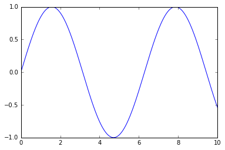

```python
%matplotlib inline
import matplotlib.pyplot as plt
x_vals = np.linspace(0, 10, num=300)
sin = np.sin(x_vals)

plt.plot(x_vals, sin)
```

# Pandas

- For tabular data
- Think: Excel, R dataframes

```python
import pandas as pd
s = pd.Series([1,3,5,np.nan,6,8])
s
```

```
0    1.0
1    3.0
2    5.0
3    NaN
4    6.0
5    8.0
dtype: float64
```

```python
dates = pd.date_range('20160101', periods=6)
dates
```

```
DatetimeIndex(['2016-01-01', '2016-01-02', '2016-01-03', '2016-01-04',
               '2016-01-05', '2016-01-06'],
              dtype='datetime64[ns]', freq='D')
```

```python
df = pd.DataFrame(np.random.randn(6,4), index=dates, columns=list('ABCD'))
df
```

|  | A | B | C | D |
| --- | --- | --- | --- | --- |
| 2016-01-01 | -0.554421 | 0.836246 | 0.228398 | -0.260706 |
| 2016-01-02 | 1.305261 | -0.782522 | 0.365541 | -1.055869 |
| 2016-01-03 | -2.220826 | 1.594428 | -0.088486 | -0.056236 |
| 2016-01-04 | 0.438015 | 1.037678 | 0.495827 | -0.065301 |
| 2016-01-05 | -1.417098 | -1.171602 | 0.361435 | 0.567672 |
| 2016-01-06 | -1.324426 | 0.343295 | 1.256941 | -0.065964 |